# machlearn_assignment

Bauke Visser

Monday, June 13, 2015

## Machine Learning assignment: Predicting manner of exercise

### Executive summary:

This project aims to use machine learning to indicate if a person is doing an excercise in a certain manner (right/wrong) by combining measurements from a number of sensors on the persons body. The study shows that this indication can be given in a very accurate way The data for this exercise come from this source: http://groupware.les.inf.puc-rio.br/har.

### Loading data

```r
library(caret)
set.seed(1)
setwd("C:/DATA/prive/R_Coursera/08 Machine Learning")
train<-read.csv("pml-training.csv", header=T)
test<-read.csv("pml-testing.csv", header=T)
```

### Exploring the data

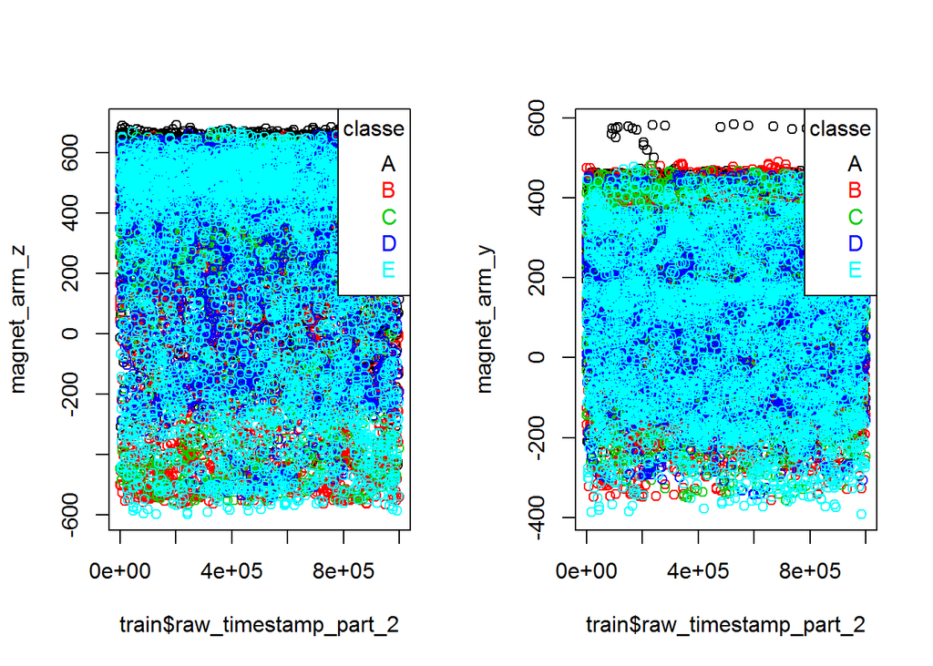

```r
t<-68
par(mfrow=c(1,2))
plot(train$raw_timestamp_part_2,train[,t],col=train$classe,ylab=colnames(train)[t])
legend("topright", legend=levels(factor(train$classe)), text.col=seq_along(levels(factor(train$classe))),title="classe")
plot(train$raw_timestamp_part_2,train[,t-1],col=train$classe,ylab=colnames(train)[t-1])
legend("topright", legend=levels(factor(train$classe)), text.col=seq_along(levels(factor(train$classe))),title="classe")
```

```r
t<-t-1
```

In this plot, the colors represent a manner of exercise. As you can see, values of a certain measurement are connected to the manner of execise. This indicates that there is a fair chance that the manner of exercise can be derived from the sensor-measurements. I added the last line so you can run the last six lines repeatedly to see more plots of different variables.

### Data preprocessing

A number of actions will be done in order to get a good dataset to train a model 1 - delete variables (columns) from the training set with a low variance 2 - delete variables from the training set that have low variance in the testset 3 - delete some columns that are expected not to contribute significantly to the model 4 - subset a pre-testset within the training set in order to estimate an out sample error

```r
nsv<-nearZeroVar(train,saveMetrics=TRUE)
sel<-nsv[nsv$nzv=="FALSE",]
train1<-train[,rownames(sel)]
test1<-test[,rownames(sel[-100,])]#exclude column "problem_id"
train2<-train1[,-c(2,5)]
test2<-test1[,-c(2,5)]

nsv1<-nearZeroVar(test2,saveMetrics=TRUE)
sel1<-nsv1[nsv1$nzv=="FALSE",]
test3<-test2[,rownames(sel1)]
train3<-train2[,rownames(sel1)]
train3$classe<-train$classe
train4<-train3[,-c(1,2,3,4)]
test4<-test3[,-c(1,2,3,4)]

inTrain = createDataPartition(train4$classe, p = 1/2)[[1]]
train5 = train4[ inTrain,]
train6 = train4[ -inTrain,]
```

### Training the model

During the preparations phase, a number of model types have been tested (gbm, svmradial, lvq) and numerous ways of tuning (control <- trainControl(method=“repeatedcv”, number=10, repeats=3)). In the end, gbm was chosen because it gives highest accuracy. Tuning can be applied but I chose not to because of speed reasons. The part below takes approx 20 minutes on a 8GB, i7 machine.

```r
modgbm<-train(classe~.,data=train5,method="gbm")
modgbm
```

```
## Stochastic Gradient Boosting
##
## 9812 samples
##   52 predictor
##    5 classes: 'A', 'B', 'C', 'D', 'E'
##
## No pre-processing
## Resampling: Bootstrapped (25 reps)
##
## Summary of sample sizes: 9812, 9812, 9812, 9812, 9812, 9812, ...
##
## Resampling results across tuning parameters:
##
##   interaction.depth  n.trees  Accuracy   Kappa      Accuracy SD
##   1                   50      0.7487751  0.6815030  0.007998883
##   1                  100      0.8180088  0.7696779  0.006895076
##   1                  150      0.8497211  0.8098325  0.006368345
##   2                   50      0.8495982  0.8094836  0.006398800
##   2                  100      0.9006358  0.8742525  0.004971574
##   2                  150      0.9239028  0.9037096  0.005195139
##   3                   50      0.8916369  0.8628101  0.006665723
##   3                  100      0.9348447  0.9175528  0.004798988
##   3                  150      0.9529799  0.9405082  0.003637502
##   Kappa SD
##   0.010255689
##   0.008732567
##   0.008075497
##   0.008137291
##   0.006281195
##   0.006575081
##   0.008446547
##   0.006076484
##   0.004607835
##
## Tuning parameter 'shrinkage' was held constant at a value of 0.1
## Accuracy was used to select the optimal model using  the largest value.
## The final values used for the model were n.trees = 150,
##  interaction.depth = 3 and shrinkage = 0.1.
```

### Estimating out of sample-error with cross validation

```r
output<-predict(modgbm,train6[,!names(train6) %in% "classe"])
cm<-confusionMatrix(data=output, reference=train6[,"classe"], positive = NULL, dnn = c("Prediction", "Reference"), prevalence = NULL)
cm$table
```

```
##           Reference
## Prediction    A    B    C    D    E
##          A 2736   60    1    7    4
##          B   31 1778   47    9   18
##          C   10   56 1651   52   19
##          D    5    1   11 1527   26
##          E    8    3    1   13 1736
```

```r
cm$overall
```

```
##       Accuracy          Kappa  AccuracyLower  AccuracyUpper   AccuracyNull
##   9.610601e-01   9.507365e-01   9.570417e-01   9.648018e-01   2.844037e-01
## AccuracyPValue  McnemarPValue
##   0.000000e+00   1.084255e-13
```

### Predicting the testset

```r
output<-predict(modgbm,test4)
output
```

```
##  [1] B A B A A E D B A A B C B A E E A B B B
## Levels: A B C D E
```

### Interpretation and conclusion

Machine Learning seems to be an effective way to indicate the manner of exercise, based on sensor data. Although there is still room for improvement, the procedure as described above, produces a very effective model with fairly accurate output.